# 2020_group07: Breast cancer analysis

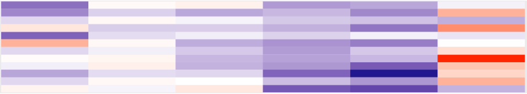

## Description

This is a project on a breast cancer proteomes dataset, which was done as part of the DTU 22100 “R for Data Science” course. The project includes an exploratory data analysis, PCA clustering, and an Artificial Neural Network (ANN) on the data.

## Data

The data for this project contains iTRAQ proteome profiling of 77 breast cancer samples from patients. The data contains protein expression values for over 12.000 proteins for each patient, however with some missing values for the proteins that could not be quantified.

The data is available in this git under */data/_raw*.

The data was originally found on Kaggle: https://www.kaggle.com/piotrgrabo/breastcancerproteomes

## Software requirements

- [R](https://cran.r-project.org/bin/windows/base/)

## Installation

The following code download this data analysis pipeline, when run in the terminal:

```
git clone https://github.com/rforbiodatascience/2020_group07
```

## Usage

To create the full data analysis the script *00.doit.R* found in */R* should be run. This will run all scripts and create all final plots. A presentation of the project can be found in */doc*.

## Group members

- Vlad Grigorjev (zidibot)
- Paula Rodriguez (paurrodri)
- Rebeka Bato (rebekabato)
- Catrine Høm (catrinehom)